# match data

#### Insights

Key Observations

- Mumbai Indians lead in toss wins: They have the highest number of toss victories, which could reflect either luck or sheer volume of matches played.
- Other consistent teams: Kolkata Knight Riders and Chennai Super Kings also feature prominently, showing they’ve had plenty of opportunities to influence match strategy through toss decisions.
- Newer/short-lived teams: Rising Pune Supergiant, Pune Supergiants, and Kochi Tuskers Kerala have very few toss wins, which makes sense given their shorter participation in the league.

#### xv) Best venue for defending and chasing a total.

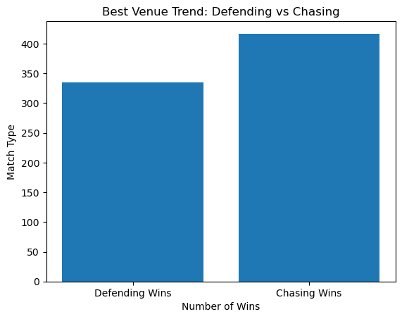

```python
import pandas as pd
import matplotlib.pyplot as plt

matches = pd.read_csv("matches.csv")

matches["defend_win"] = matches["winner"] == matches["team1"]

matches["chase_win"] = matches["winner"] == matches["team2"]

venue_stats = matches.groupby("venue").agg({
    "defend_win": "sum",
    "chase_win": "sum"
}).sum()

labels = ["Defending Wins", "Chasing Wins"]
values = [venue_stats["defend_win"], venue_stats["chase_win"]]

plt.figure()
plt.bar(labels, values)
plt.title("Best Venue Trend: Defending vs Chasing")
plt.xlabel("Number of Wins")
plt.ylabel("Match Type")

plt.show()
```

#### Insights

Key Observations

- Chasing wins dominate: Teams have won slightly more matches while chasing (just above 400) compared to defending (just below 350).
- Modern trend confirmed: This aligns with captains’ preference to field first (from the earlier chart), showing that chasing is statistically more successful.

#### xvi) Best defending and chasing teams.

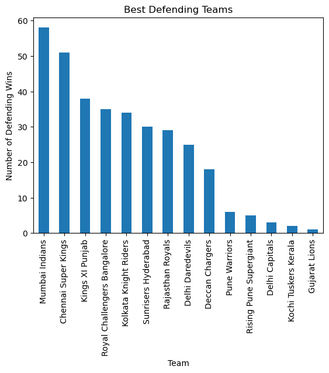

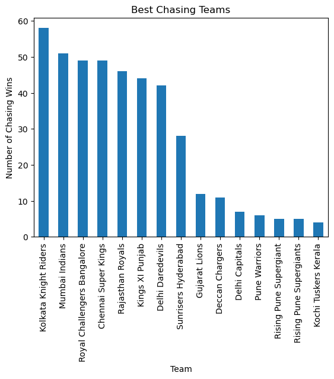

```python
import pandas as pd
import matplotlib.pyplot as plt

matches = pd.read_csv("matches.csv")

defend_wins = matches[matches["winner"] == matches["team1"]]["winner"].value_counts()

chase_wins = matches[matches["winner"] == matches["team2"]]["winner"].value_counts()

plt.figure()
defend_wins.plot(kind="bar")
plt.title("Best Defending Teams")
plt.xlabel("Team")
plt.ylabel("Number of Defending Wins")
plt.xticks(rotation=90)
plt.show()

plt.figure()
chase_wins.plot(kind="bar")
plt.title("Best Chasing Teams")
plt.xlabel("Team")
plt.ylabel("Number of Chasing Wins")
plt.xticks(rotation=90)
plt.show()
```